# Risk Factor Analysis

## Outcome Variable

**Outcome Variable:** ever_swasted

## Predictor Variables

**Intervention Variable:** sex

**Adjustment Set:**

unadjusted

## Stratifying Variables

The analysis was stratified on these variable(s):

- agecat
- studyid
- country

## Data Summary

| agecat | studyid | country | sex | ever_swasted | n_cell | n |
| --- | --- | --- | --- | --- | --- | --- |
| 0-24 months | CMC-V-BCS-2002 | INDIA | Female | 0 | 144 | 373 |
| 0-24 months | CMC-V-BCS-2002 | INDIA | Female | 1 | 43 | 373 |
| 0-24 months | CMC-V-BCS-2002 | INDIA | Male | 0 | 137 | 373 |
| 0-24 months | CMC-V-BCS-2002 | INDIA | Male | 1 | 49 | 373 |
| 0-24 months | CMIN | BANGLADESH | Female | 0 | 101 | 272 |
| 0-24 months | CMIN | BANGLADESH | Female | 1 | 18 | 272 |
| 0-24 months | CMIN | BANGLADESH | Male | 0 | 129 | 272 |
| 0-24 months | CMIN | BANGLADESH | Male | 1 | 24 | 272 |
| 0-24 months | COHORTS | GUATEMALA | Female | 0 | 599 | 1349 |
| 0-24 months | COHORTS | GUATEMALA | Female | 1 | 36 | 1349 |
| 0-24 months | COHORTS | GUATEMALA | Male | 0 | 653 | 1349 |
| 0-24 months | COHORTS | GUATEMALA | Male | 1 | 61 | 1349 |
| 0-24 months | COHORTS | INDIA | Female | 0 | 3185 | 7405 |
| 0-24 months | COHORTS | INDIA | Female | 1 | 366 | 7405 |
| 0-24 months | COHORTS | INDIA | Male | 0 | 3444 | 7405 |
| 0-24 months | COHORTS | INDIA | Male | 1 | 410 | 7405 |
| 0-24 months | COHORTS | PHILIPPINES | Female | 0 | 1274 | 3045 |
| 0-24 months | COHORTS | PHILIPPINES | Female | 1 | 157 | 3045 |
| 0-24 months | COHORTS | PHILIPPINES | Male | 0 | 1389 | 3045 |
| 0-24 months | COHORTS | PHILIPPINES | Male | 1 | 225 | 3045 |
| 0-24 months | CONTENT | PERU | Female | 0 | 109 | 215 |
| 0-24 months | CONTENT | PERU | Female | 1 | 0 | 215 |
| 0-24 months | CONTENT | PERU | Male | 0 | 105 | 215 |
| 0-24 months | CONTENT | PERU | Male | 1 | 1 | 215 |
| 0-24 months | EE | PAKISTAN | Female | 0 | 153 | 380 |
| 0-24 months | EE | PAKISTAN | Female | 1 | 32 | 380 |
| 0-24 months | EE | PAKISTAN | Male | 0 | 147 | 380 |
| 0-24 months | EE | PAKISTAN | Male | 1 | 48 | 380 |
| 0-24 months | GMS-Nepal | NEPAL | Female | 0 | 239 | 686 |
| 0-24 months | GMS-Nepal | NEPAL | Female | 1 | 83 | 686 |

[output cut: 314 more lines]

The following strata were considered:

- agecat: 0-24 months, studyid: CMC-V-BCS-2002, country: INDIA
- agecat: 0-24 months, studyid: CMIN, country: BANGLADESH
- agecat: 0-24 months, studyid: COHORTS, country: GUATEMALA
- agecat: 0-24 months, studyid: COHORTS, country: INDIA
- agecat: 0-24 months, studyid: COHORTS, country: PHILIPPINES
- agecat: 0-24 months, studyid: CONTENT, country: PERU
- agecat: 0-24 months, studyid: EE, country: PAKISTAN
- agecat: 0-24 months, studyid: GMS-Nepal, country: NEPAL
- agecat: 0-24 months, studyid: Guatemala BSC, country: GUATEMALA
- agecat: 0-24 months, studyid: iLiNS-Zinc, country: BURKINA FASO
- agecat: 0-24 months, studyid: IRC, country: INDIA
- agecat: 0-24 months, studyid: Keneba, country: GAMBIA
- agecat: 0-24 months, studyid: LCNI-5, country: MALAWI
- agecat: 0-24 months, studyid: MAL-ED, country: BANGLADESH
- agecat: 0-24 months, studyid: MAL-ED, country: BRAZIL
- agecat: 0-24 months, studyid: MAL-ED, country: INDIA
- agecat: 0-24 months, studyid: MAL-ED, country: NEPAL
- agecat: 0-24 months, studyid: MAL-ED, country: PERU
- agecat: 0-24 months, studyid: MAL-ED, country: SOUTH AFRICA
- agecat: 0-24 months, studyid: MAL-ED, country: TANZANIA, UNITED REPUBLIC OF
- agecat: 0-24 months, studyid: NIH-Birth, country: BANGLADESH
- agecat: 0-24 months, studyid: NIH-Crypto, country: BANGLADESH
- agecat: 0-24 months, studyid: PROBIT, country: BELARUS
- agecat: 0-24 months, studyid: PROVIDE, country: BANGLADESH
- agecat: 0-24 months, studyid: ResPak, country: PAKISTAN
- agecat: 0-24 months, studyid: SAS-CompFeed, country: INDIA
- agecat: 0-24 months, studyid: SAS-FoodSuppl, country: INDIA
- agecat: 0-24 months, studyid: TanzaniaChild2, country: TANZANIA, UNITED REPUBLIC OF
- agecat: 0-24 months, studyid: ZVITAMBO, country: ZIMBABWE
- agecat: 0-6 months, studyid: CMC-V-BCS-2002, country: INDIA
- agecat: 0-6 months, studyid: CMIN, country: BANGLADESH
- agecat: 0-6 months, studyid: COHORTS, country: GUATEMALA
- agecat: 0-6 months, studyid: COHORTS, country: INDIA
- agecat: 0-6 months, studyid: COHORTS, country: PHILIPPINES
- agecat: 0-6 months, studyid: CONTENT, country: PERU
- agecat: 0-6 months, studyid: EE, country: PAKISTAN
- agecat: 0-6 months, studyid: GMS-Nepal, country: NEPAL
- agecat: 0-6 months, studyid: Guatemala BSC, country: GUATEMALA
- agecat: 0-6 months, studyid: IRC, country: INDIA
- agecat: 0-6 months, studyid: Keneba, country: GAMBIA
- agecat: 0-6 months, studyid: LCNI-5, country: MALAWI
- agecat: 0-6 months, studyid: MAL-ED, country: BANGLADESH
- agecat: 0-6 months, studyid: MAL-ED, country: BRAZIL
- agecat: 0-6 months, studyid: MAL-ED, country: INDIA
- agecat: 0-6 months, studyid: MAL-ED, country: NEPAL
- agecat: 0-6 months, studyid: MAL-ED, country: PERU
- agecat: 0-6 months, studyid: MAL-ED, country: SOUTH AFRICA
- agecat: 0-6 months, studyid: MAL-ED, country: TANZANIA, UNITED REPUBLIC OF
- agecat: 0-6 months, studyid: NIH-Birth, country: BANGLADESH
- agecat: 0-6 months, studyid: NIH-Crypto, country: BANGLADESH
- agecat: 0-6 months, studyid: PROBIT, country: BELARUS
- agecat: 0-6 months, studyid: PROVIDE, country: BANGLADESH
- agecat: 0-6 months, studyid: ResPak, country: PAKISTAN
- agecat: 0-6 months, studyid: SAS-CompFeed, country: INDIA
- agecat: 0-6 months, studyid: SAS-FoodSuppl, country: INDIA
- agecat: 0-6 months, studyid: TanzaniaChild2, country: TANZANIA, UNITED REPUBLIC OF
- agecat: 0-6 months, studyid: ZVITAMBO, country: ZIMBABWE
- agecat: 6-24 months, studyid: CMC-V-BCS-2002, country: INDIA
- agecat: 6-24 months, studyid: CMIN, country: BANGLADESH
- agecat: 6-24 months, studyid: COHORTS, country: GUATEMALA
- agecat: 6-24 months, studyid: COHORTS, country: INDIA
- agecat: 6-24 months, studyid: COHORTS, country: PHILIPPINES
- agecat: 6-24 months, studyid: CONTENT, country: PERU
- agecat: 6-24 months, studyid: EE, country: PAKISTAN
- agecat: 6-24 months, studyid: GMS-Nepal, country: NEPAL
- agecat: 6-24 months, studyid: Guatemala BSC, country: GUATEMALA
- agecat: 6-24 months, studyid: iLiNS-Zinc, country: BURKINA FASO
- agecat: 6-24 months, studyid: IRC, country: INDIA
- agecat: 6-24 months, studyid: Keneba, country: GAMBIA
- agecat: 6-24 months, studyid: LCNI-5, country: MALAWI
- agecat: 6-24 months, studyid: MAL-ED, country: BANGLADESH
- agecat: 6-24 months, studyid: MAL-ED, country: BRAZIL
- agecat: 6-24 months, studyid: MAL-ED, country: INDIA
- agecat: 6-24 months, studyid: MAL-ED, country: NEPAL
- agecat: 6-24 months, studyid: MAL-ED, country: PERU
- agecat: 6-24 months, studyid: MAL-ED, country: SOUTH AFRICA
- agecat: 6-24 months, studyid: MAL-ED, country: TANZANIA, UNITED REPUBLIC OF
- agecat: 6-24 months, studyid: NIH-Birth, country: BANGLADESH
- agecat: 6-24 months, studyid: NIH-Crypto, country: BANGLADESH
- agecat: 6-24 months, studyid: PROBIT, country: BELARUS
- agecat: 6-24 months, studyid: PROVIDE, country: BANGLADESH
- agecat: 6-24 months, studyid: ResPak, country: PAKISTAN
- agecat: 6-24 months, studyid: SAS-CompFeed, country: INDIA
- agecat: 6-24 months, studyid: SAS-FoodSuppl, country: INDIA
- agecat: 6-24 months, studyid: TanzaniaChild2, country: TANZANIA, UNITED REPUBLIC OF
- agecat: 6-24 months, studyid: ZVITAMBO, country: ZIMBABWE

### Dropped Strata

Some strata were dropped due to rare outcomes:

- agecat: 0-24 months, studyid: CONTENT, country: PERU
- agecat: 0-24 months, studyid: Guatemala BSC, country: GUATEMALA
- agecat: 0-24 months, studyid: LCNI-5, country: MALAWI
- agecat: 0-24 months, studyid: MAL-ED, country: BRAZIL
- agecat: 0-24 months, studyid: MAL-ED, country: NEPAL
- agecat: 0-24 months, studyid: MAL-ED, country: PERU
- agecat: 0-24 months, studyid: MAL-ED, country: TANZANIA, UNITED REPUBLIC OF
- agecat: 0-6 months, studyid: CONTENT, country: PERU
- agecat: 0-6 months, studyid: Guatemala BSC, country: GUATEMALA
- agecat: 0-6 months, studyid: LCNI-5, country: MALAWI
- agecat: 0-6 months, studyid: MAL-ED, country: BRAZIL
- agecat: 0-6 months, studyid: MAL-ED, country: NEPAL
- agecat: 0-6 months, studyid: MAL-ED, country: PERU
- agecat: 0-6 months, studyid: MAL-ED, country: SOUTH AFRICA
- agecat: 0-6 months, studyid: MAL-ED, country: TANZANIA, UNITED REPUBLIC OF
- agecat: 6-24 months, studyid: CONTENT, country: PERU
- agecat: 6-24 months, studyid: Guatemala BSC, country: GUATEMALA
- agecat: 6-24 months, studyid: LCNI-5, country: MALAWI
- agecat: 6-24 months, studyid: MAL-ED, country: BANGLADESH
- agecat: 6-24 months, studyid: MAL-ED, country: BRAZIL
- agecat: 6-24 months, studyid: MAL-ED, country: INDIA
- agecat: 6-24 months, studyid: MAL-ED, country: NEPAL
- agecat: 6-24 months, studyid: MAL-ED, country: PERU
- agecat: 6-24 months, studyid: MAL-ED, country: TANZANIA, UNITED REPUBLIC OF
- agecat: 6-24 months, studyid: PROBIT, country: BELARUS

## Methods Detail

We’re interested in the causal parameters $E[Y_a]$ for all values of $a \in \mathcal{A}$. These parameters represent the mean outcome if, possibly contrary to fact, we intervened to set all units to have $A=a$. Under the randomization and positivity assumptions, these are identified by the statistical parameters $\psi_a=E_W[E_{Y|A,W}(Y|A=a,W)]$. In addition, we’re interested in the mean of $Y$, $E[Y]$ under no intervention (the observed mean). We will estimate these parameters by using SuperLearner to fit the relevant likelihood factors – $E_{Y|A,W}(Y|A=a,W)$ and $p(A=a|W)$, and then updating our likelihood fit using a joint TMLE.

For unadjusted analyses ($W=\{\}$), initial likelihoods were estimated using Lrnr_glm to estimate the simple $E(Y|A)$ and Lrnr_mean to estimate $p(A)$. For adjusted analyses, a small library containing Lrnr_glmnet, Lrnr_xgboost, and Lrnr_mean was used.

Having estimated these parameters, we will then use the delta method to estimate relative risks and attributable risks relative to a prespecified baseline level of $A$.

# Results Detail

## Results Plots

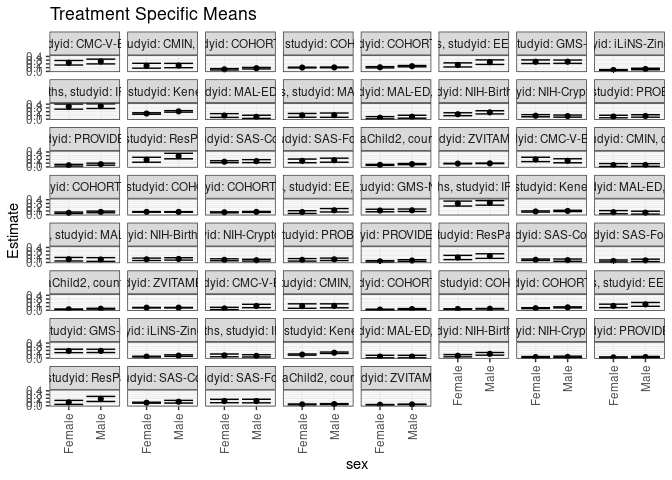

[figure not shown]

[figure not shown]

[figure not shown]

## Results Table

### Parameter: TSM

| agecat | studyid | country | intervention_level | baseline_level | estimate | ci_lower | ci_upper |
| --- | --- | --- | --- | --- | --- | --- | --- |
| 0-24 months | CMC-V-BCS-2002 | INDIA | Female | NA | 0.2299465 | 0.1695539 | 0.2903392 |
| 0-24 months | CMC-V-BCS-2002 | INDIA | Male | NA | 0.2634409 | 0.2000510 | 0.3268307 |
| 0-24 months | CMIN | BANGLADESH | Female | NA | 0.1512605 | 0.0867657 | 0.2157553 |
| 0-24 months | CMIN | BANGLADESH | Male | NA | 0.1568627 | 0.0991315 | 0.2145940 |
| 0-24 months | COHORTS | GUATEMALA | Female | NA | 0.0566929 | 0.0386995 | 0.0746863 |
| 0-24 months | COHORTS | GUATEMALA | Male | NA | 0.0854342 | 0.0649233 | 0.1059450 |
| 0-24 months | COHORTS | INDIA | Female | NA | 0.1030696 | 0.0930685 | 0.1130706 |
| 0-24 months | COHORTS | INDIA | Male | NA | 0.1063830 | 0.0966480 | 0.1161179 |
| 0-24 months | COHORTS | PHILIPPINES | Female | NA | 0.1097135 | 0.0935180 | 0.1259090 |
| 0-24 months | COHORTS | PHILIPPINES | Male | NA | 0.1394052 | 0.1225044 | 0.1563060 |
| 0-24 months | EE | PAKISTAN | Female | NA | 0.1729730 | 0.1183993 | 0.2275467 |
| 0-24 months | EE | PAKISTAN | Male | NA | 0.2461538 | 0.1856131 | 0.3066946 |
| 0-24 months | GMS-Nepal | NEPAL | Female | NA | 0.2577640 | 0.2099539 | 0.3055740 |
| 0-24 months | GMS-Nepal | NEPAL | Male | NA | 0.2582418 | 0.2132473 | 0.3032362 |
| 0-24 months | iLiNS-Zinc | BURKINA FASO | Female | NA | 0.0369231 | 0.0259852 | 0.0478610 |
| 0-24 months | iLiNS-Zinc | BURKINA FASO | Male | NA | 0.0639854 | 0.0442101 | 0.0837606 |
| 0-24 months | IRC | INDIA | Female | NA | 0.3351351 | 0.2670317 | 0.4032386 |
| 0-24 months | IRC | INDIA | Male | NA | 0.3466667 | 0.2844065 | 0.4089269 |
| 0-24 months | Keneba | GAMBIA | Female | NA | 0.1509568 | 0.1322736 | 0.1696399 |
| 0-24 months | Keneba | GAMBIA | Male | NA | 0.2074221 | 0.1869612 | 0.2278831 |
| 0-24 months | MAL-ED | BANGLADESH | Female | NA | 0.0970149 | 0.0468058 | 0.1472240 |
| 0-24 months | MAL-ED | BANGLADESH | Male | NA | 0.0620155 | 0.0203162 | 0.1037148 |
| 0-24 months | MAL-ED | INDIA | Female | NA | 0.1014493 | 0.0509749 | 0.1519237 |
| 0-24 months | MAL-ED | INDIA | Male | NA | 0.1061947 | 0.0492768 | 0.1631126 |
| 0-24 months | MAL-ED | SOUTH AFRICA | Female | NA | 0.0379747 | 0.0081238 | 0.0678256 |
| 0-24 months | MAL-ED | SOUTH AFRICA | Male | NA | 0.0649351 | 0.0259547 | 0.1039154 |
| 0-24 months | NIH-Birth | BANGLADESH | Female | NA | 0.1317568 | 0.0931949 | 0.1703186 |
| 0-24 months | NIH-Birth | BANGLADESH | Male | NA | 0.1829268 | 0.1410544 | 0.2247993 |
| 0-24 months | NIH-Crypto | BANGLADESH | Female | NA | 0.0918635 | 0.0628421 | 0.1208850 |
| 0-24 months | NIH-Crypto | BANGLADESH | Male | NA | 0.0822281 | 0.0544795 | 0.1099768 |

[output cut: 92 more lines]

### Parameter: E(Y)

| agecat | studyid | country | intervention_level | baseline_level | estimate | ci_lower | ci_upper |
| --- | --- | --- | --- | --- | --- | --- | --- |
| 0-24 months | CMC-V-BCS-2002 | INDIA | NA | NA | 0.2466488 | 0.2028447 | 0.2904529 |
| 0-24 months | CMIN | BANGLADESH | NA | NA | 0.1544118 | 0.1113905 | 0.1974330 |
| 0-24 months | COHORTS | GUATEMALA | NA | NA | 0.0719051 | 0.0581146 | 0.0856956 |
| 0-24 months | COHORTS | INDIA | NA | NA | 0.1047941 | 0.0978174 | 0.1117707 |
| 0-24 months | COHORTS | PHILIPPINES | NA | NA | 0.1254516 | 0.1136848 | 0.1372183 |
| 0-24 months | EE | PAKISTAN | NA | NA | 0.2105263 | 0.1694822 | 0.2515704 |
| 0-24 months | GMS-Nepal | NEPAL | NA | NA | 0.2580175 | 0.2252514 | 0.2907836 |
| 0-24 months | iLiNS-Zinc | BURKINA FASO | NA | NA | 0.0505205 | 0.0383088 | 0.0627322 |
| 0-24 months | IRC | INDIA | NA | NA | 0.3414634 | 0.2955068 | 0.3874201 |
| 0-24 months | Keneba | GAMBIA | NA | NA | 0.1801370 | 0.1661957 | 0.1940783 |
| 0-24 months | MAL-ED | BANGLADESH | NA | NA | 0.0798479 | 0.0470264 | 0.1126695 |
| 0-24 months | MAL-ED | INDIA | NA | NA | 0.1035857 | 0.0658126 | 0.1413587 |
| 0-24 months | MAL-ED | SOUTH AFRICA | NA | NA | 0.0512821 | 0.0267678 | 0.0757963 |
| 0-24 months | NIH-Birth | BANGLADESH | NA | NA | 0.1586538 | 0.1299648 | 0.1873429 |
| 0-24 months | NIH-Crypto | BANGLADESH | NA | NA | 0.0870712 | 0.0669870 | 0.1071555 |
| 0-24 months | PROBIT | BELARUS | NA | NA | 0.0784116 | 0.0458146 | 0.1110087 |
| 0-24 months | PROVIDE | BANGLADESH | NA | NA | 0.0600000 | 0.0423945 | 0.0776055 |
| 0-24 months | ResPak | PAKISTAN | NA | NA | 0.2429577 | 0.1929911 | 0.2929244 |
| 0-24 months | SAS-CompFeed | INDIA | NA | NA | 0.1473893 | 0.1184132 | 0.1763654 |
| 0-24 months | SAS-FoodSuppl | INDIA | NA | NA | 0.1698565 | 0.1338154 | 0.2058975 |
| 0-24 months | TanzaniaChild2 | TANZANIA, UNITED REPUBLIC OF | NA | NA | 0.0659432 | 0.0560037 | 0.0758828 |
| 0-24 months | ZVITAMBO | ZIMBABWE | NA | NA | 0.0922128 | 0.0874108 | 0.0970149 |
| 0-6 months | CMC-V-BCS-2002 | INDIA | NA | NA | 0.1820652 | 0.1425842 | 0.2215462 |
| 0-6 months | CMIN | BANGLADESH | NA | NA | 0.0514706 | 0.0251638 | 0.0777774 |
| 0-6 months | COHORTS | GUATEMALA | NA | NA | 0.0629699 | 0.0483675 | 0.0775723 |
| 0-6 months | COHORTS | INDIA | NA | NA | 0.0744949 | 0.0683989 | 0.0805910 |
| 0-6 months | COHORTS | PHILIPPINES | NA | NA | 0.0693167 | 0.0602923 | 0.0783411 |
| 0-6 months | EE | PAKISTAN | NA | NA | 0.0947368 | 0.0652536 | 0.1242201 |
| 0-6 months | GMS-Nepal | NEPAL | NA | NA | 0.1151603 | 0.0912555 | 0.1390652 |
| 0-6 months | IRC | INDIA | NA | NA | 0.3073171 | 0.2626027 | 0.3520314 |
| 0-6 months | Keneba | GAMBIA | NA | NA | 0.0936740 | 0.0821715 | 0.1051764 |
| 0-6 months | MAL-ED | BANGLADESH | NA | NA | 0.0608365 | 0.0318931 | 0.0897799 |
| 0-6 months | MAL-ED | INDIA | NA | NA | 0.0836653 | 0.0493429 | 0.1179878 |
| 0-6 months | NIH-Birth | BANGLADESH | NA | NA | 0.0900322 | 0.0675202 | 0.1125442 |
| 0-6 months | NIH-Crypto | BANGLADESH | NA | NA | 0.0659631 | 0.0482810 | 0.0836451 |
| 0-6 months | PROBIT | BELARUS | NA | NA | 0.0777153 | 0.0450748 | 0.1103558 |
| 0-6 months | PROVIDE | BANGLADESH | NA | NA | 0.0414286 | 0.0266555 | 0.0562017 |
| 0-6 months | ResPak | PAKISTAN | NA | NA | 0.1524823 | 0.1104504 | 0.1945142 |
| 0-6 months | SAS-CompFeed | INDIA | NA | NA | 0.0664452 | 0.0425975 | 0.0902929 |
| 0-6 months | SAS-FoodSuppl | INDIA | NA | NA | 0.0478469 | 0.0273607 | 0.0683330 |
| 0-6 months | TanzaniaChild2 | TANZANIA, UNITED REPUBLIC OF | NA | NA | 0.0329716 | 0.0258203 | 0.0401229 |
| 0-6 months | ZVITAMBO | ZIMBABWE | NA | NA | 0.0687938 | 0.0645788 | 0.0730087 |
| 6-24 months | CMC-V-BCS-2002 | INDIA | NA | NA | 0.0804290 | 0.0527929 | 0.1080650 |
| 6-24 months | CMIN | BANGLADESH | NA | NA | 0.1150794 | 0.0756007 | 0.1545580 |
| 6-24 months | COHORTS | GUATEMALA | NA | NA | 0.0245902 | 0.0158961 | 0.0332842 |
| 6-24 months | COHORTS | INDIA | NA | NA | 0.0367382 | 0.0323123 | 0.0411641 |
| 6-24 months | COHORTS | PHILIPPINES | NA | NA | 0.0669277 | 0.0576848 | 0.0761707 |
| 6-24 months | EE | PAKISTAN | NA | NA | 0.1363636 | 0.1015372 | 0.1711900 |
| 6-24 months | GMS-Nepal | NEPAL | NA | NA | 0.1898305 | 0.1581595 | 0.2215015 |
| 6-24 months | iLiNS-Zinc | BURKINA FASO | NA | NA | 0.0505205 | 0.0383088 | 0.0627322 |
| 6-24 months | IRC | INDIA | NA | NA | 0.0634146 | 0.0397960 | 0.0870333 |
| 6-24 months | Keneba | GAMBIA | NA | NA | 0.1172389 | 0.1051866 | 0.1292911 |
| 6-24 months | MAL-ED | SOUTH AFRICA | NA | NA | 0.0386100 | 0.0151008 | 0.0621193 |
| 6-24 months | NIH-Birth | BANGLADESH | NA | NA | 0.0885609 | 0.0646203 | 0.1125014 |
| 6-24 months | NIH-Crypto | BANGLADESH | NA | NA | 0.0273973 | 0.0155476 | 0.0392469 |
| 6-24 months | PROVIDE | BANGLADESH | NA | NA | 0.0211382 | 0.0097604 | 0.0325160 |
| 6-24 months | ResPak | PAKISTAN | NA | NA | 0.1398305 | 0.0954893 | 0.1841717 |
| 6-24 months | SAS-CompFeed | INDIA | NA | NA | 0.0964723 | 0.0729872 | 0.1199573 |
| 6-24 months | SAS-FoodSuppl | INDIA | NA | NA | 0.1268657 | 0.0942904 | 0.1594410 |
| 6-24 months | TanzaniaChild2 | TANZANIA, UNITED REPUBLIC OF | NA | NA | 0.0411298 | 0.0324631 | 0.0497965 |
| 6-24 months | ZVITAMBO | ZIMBABWE | NA | NA | 0.0329172 | 0.0295545 | 0.0362800 |

### Parameter: RR

| agecat | studyid | country | intervention_level | baseline_level | estimate | ci_lower | ci_upper |
| --- | --- | --- | --- | --- | --- | --- | --- |
| 0-24 months | CMC-V-BCS-2002 | INDIA | Female | Female | 1.0000000 | 1.0000000 | 1.000000 |
| 0-24 months | CMC-V-BCS-2002 | INDIA | Male | Female | 1.1456614 | 0.8023445 | 1.635881 |
| 0-24 months | CMIN | BANGLADESH | Female | Female | 1.0000000 | 1.0000000 | 1.000000 |
| 0-24 months | CMIN | BANGLADESH | Male | Female | 1.0370370 | 0.5904417 | 1.821426 |
| 0-24 months | COHORTS | GUATEMALA | Female | Female | 1.0000000 | 1.0000000 | 1.000000 |
| 0-24 months | COHORTS | GUATEMALA | Male | Female | 1.5069639 | 1.0122142 | 2.243537 |
| 0-24 months | COHORTS | INDIA | Female | Female | 1.0000000 | 1.0000000 | 1.000000 |
| 0-24 months | COHORTS | INDIA | Male | Female | 1.0321474 | 0.9032697 | 1.179413 |
| 0-24 months | COHORTS | PHILIPPINES | Female | Female | 1.0000000 | 1.0000000 | 1.000000 |
| 0-24 months | COHORTS | PHILIPPINES | Male | Female | 1.2706296 | 1.0496880 | 1.538076 |
| 0-24 months | EE | PAKISTAN | Female | Female | 1.0000000 | 1.0000000 | 1.000000 |
| 0-24 months | EE | PAKISTAN | Male | Female | 1.4230769 | 0.9538780 | 2.123068 |
| 0-24 months | GMS-Nepal | NEPAL | Female | Female | 1.0000000 | 1.0000000 | 1.000000 |
| 0-24 months | GMS-Nepal | NEPAL | Male | Female | 1.0018536 | 0.7767565 | 1.292182 |
| 0-24 months | iLiNS-Zinc | BURKINA FASO | Female | Female | 1.0000000 | 1.0000000 | 1.000000 |
| 0-24 months | iLiNS-Zinc | BURKINA FASO | Male | Female | 1.7329372 | 1.1929166 | 2.517419 |
| 0-24 months | IRC | INDIA | Female | Female | 1.0000000 | 1.0000000 | 1.000000 |
| 0-24 months | IRC | INDIA | Male | Female | 1.0344086 | 0.7886984 | 1.356667 |
| 0-24 months | Keneba | GAMBIA | Female | Female | 1.0000000 | 1.0000000 | 1.000000 |
| 0-24 months | Keneba | GAMBIA | Male | Female | 1.3740499 | 1.1729191 | 1.609670 |
| 0-24 months | MAL-ED | BANGLADESH | Female | Female | 1.0000000 | 1.0000000 | 1.000000 |
| 0-24 months | MAL-ED | BANGLADESH | Male | Female | 0.6392367 | 0.2736265 | 1.493362 |
| 0-24 months | MAL-ED | INDIA | Female | Female | 1.0000000 | 1.0000000 | 1.000000 |
| 0-24 months | MAL-ED | INDIA | Male | Female | 1.0467762 | 0.5037919 | 2.174987 |
| 0-24 months | MAL-ED | SOUTH AFRICA | Female | Female | 1.0000000 | 1.0000000 | 1.000000 |
| 0-24 months | MAL-ED | SOUTH AFRICA | Male | Female | 1.7099567 | 0.6359688 | 4.597634 |
| 0-24 months | NIH-Birth | BANGLADESH | Female | Female | 1.0000000 | 1.0000000 | 1.000000 |
| 0-24 months | NIH-Birth | BANGLADESH | Male | Female | 1.3883677 | 0.9575010 | 2.013121 |
| 0-24 months | NIH-Crypto | BANGLADESH | Female | Female | 1.0000000 | 1.0000000 | 1.000000 |
| 0-24 months | NIH-Crypto | BANGLADESH | Male | Female | 0.8951118 | 0.5637941 | 1.421131 |

[output cut: 92 more lines]

### Parameter: PAR

| agecat | studyid | country | intervention_level | baseline_level | estimate | ci_lower | ci_upper |
| --- | --- | --- | --- | --- | --- | --- | --- |
| 0-24 months | CMC-V-BCS-2002 | INDIA | Female | NA | 0.0167023 | -0.0269901 | 0.0603946 |
| 0-24 months | CMIN | BANGLADESH | Female | NA | 0.0031513 | -0.0455393 | 0.0518419 |
| 0-24 months | COHORTS | GUATEMALA | Female | NA | 0.0152122 | 0.0007506 | 0.0296738 |
| 0-24 months | COHORTS | INDIA | Female | NA | 0.0017245 | -0.0055395 | 0.0089885 |
| 0-24 months | COHORTS | PHILIPPINES | Female | NA | 0.0157381 | 0.0033196 | 0.0281566 |
| 0-24 months | EE | PAKISTAN | Female | NA | 0.0375533 | -0.0044347 | 0.0795413 |
| 0-24 months | GMS-Nepal | NEPAL | Female | NA | 0.0002535 | -0.0345827 | 0.0350897 |
| 0-24 months | iLiNS-Zinc | BURKINA FASO | Female | NA | 0.0135974 | 0.0038513 | 0.0233436 |
| 0-24 months | IRC | INDIA | Female | NA | 0.0063283 | -0.0443127 | 0.0569693 |
| 0-24 months | Keneba | GAMBIA | Female | NA | 0.0291802 | 0.0148249 | 0.0435355 |
| 0-24 months | MAL-ED | BANGLADESH | Female | NA | -0.0171670 | -0.0492501 | 0.0149161 |
| 0-24 months | MAL-ED | INDIA | Female | NA | 0.0021364 | -0.0321135 | 0.0363862 |
| 0-24 months | MAL-ED | SOUTH AFRICA | Female | NA | 0.0133074 | -0.0109728 | 0.0375875 |
| 0-24 months | NIH-Birth | BANGLADESH | Female | NA | 0.0268971 | -0.0030916 | 0.0568858 |
| 0-24 months | NIH-Crypto | BANGLADESH | Female | NA | -0.0047923 | -0.0247656 | 0.0151810 |
| 0-24 months | PROBIT | BELARUS | Female | NA | 0.0078941 | 0.0027350 | 0.0130532 |
| 0-24 months | PROVIDE | BANGLADESH | Female | NA | 0.0148193 | -0.0035018 | 0.0331404 |
| 0-24 months | ResPak | PAKISTAN | Female | NA | 0.0517813 | -0.0000055 | 0.1035680 |
| 0-24 months | SAS-CompFeed | INDIA | Female | NA | 0.0089053 | -0.0115075 | 0.0293181 |
| 0-24 months | SAS-FoodSuppl | INDIA | Female | NA | 0.0084215 | -0.0253776 | 0.0422205 |
| 0-24 months | TanzaniaChild2 | TANZANIA, UNITED REPUBLIC OF | Female | NA | 0.0102000 | 0.0001605 | 0.0202395 |
| 0-24 months | ZVITAMBO | ZIMBABWE | Female | NA | 0.0029139 | -0.0020226 | 0.0078504 |
| 0-6 months | CMC-V-BCS-2002 | INDIA | Female | NA | -0.0179348 | -0.0571858 | 0.0213162 |
| 0-6 months | CMIN | BANGLADESH | Female | NA | 0.0010504 | -0.0287146 | 0.0308154 |
| 0-6 months | COHORTS | GUATEMALA | Female | NA | 0.0116879 | -0.0034967 | 0.0268724 |
| 0-6 months | COHORTS | INDIA | Female | NA | -0.0004472 | -0.0067318 | 0.0058375 |
| 0-6 months | COHORTS | PHILIPPINES | Female | NA | 0.0057248 | -0.0038146 | 0.0152642 |
| 0-6 months | EE | PAKISTAN | Female | NA | 0.0244666 | -0.0056176 | 0.0545507 |
| 0-6 months | GMS-Nepal | NEPAL | Female | NA | 0.0033591 | -0.0220196 | 0.0287378 |
| 0-6 months | IRC | INDIA | Female | NA | 0.0100198 | -0.0392106 | 0.0592501 |
| 0-6 months | Keneba | GAMBIA | Female | NA | 0.0077430 | -0.0041647 | 0.0196508 |
| 0-6 months | MAL-ED | BANGLADESH | Female | NA | -0.0063277 | -0.0346728 | 0.0220174 |
| 0-6 months | MAL-ED | INDIA | Female | NA | -0.0032912 | -0.0342269 | 0.0276445 |
| 0-6 months | NIH-Birth | BANGLADESH | Female | NA | 0.0052864 | -0.0183533 | 0.0289261 |
| 0-6 months | NIH-Crypto | BANGLADESH | Female | NA | -0.0049031 | -0.0224857 | 0.0126795 |
| 0-6 months | PROBIT | BELARUS | Female | NA | 0.0071805 | 0.0019967 | 0.0123642 |
| 0-6 months | PROVIDE | BANGLADESH | Female | NA | 0.0113081 | -0.0040429 | 0.0266591 |
| 0-6 months | ResPak | PAKISTAN | Female | NA | 0.0201293 | -0.0232540 | 0.0635127 |
| 0-6 months | SAS-CompFeed | INDIA | Female | NA | -0.0051922 | -0.0163823 | 0.0059978 |
| 0-6 months | SAS-FoodSuppl | INDIA | Female | NA | 0.0074881 | -0.0118738 | 0.0268501 |
| 0-6 months | TanzaniaChild2 | TANZANIA, UNITED REPUBLIC OF | Female | NA | 0.0076338 | 0.0004173 | 0.0148503 |
| 0-6 months | ZVITAMBO | ZIMBABWE | Female | NA | 0.0006187 | -0.0037240 | 0.0049614 |
| 6-24 months | CMC-V-BCS-2002 | INDIA | Female | NA | 0.0323006 | 0.0047104 | 0.0598908 |
| 6-24 months | CMIN | BANGLADESH | Female | NA | 0.0039683 | -0.0414456 | 0.0493821 |
| 6-24 months | COHORTS | GUATEMALA | Female | NA | 0.0074375 | -0.0015350 | 0.0164101 |
| 6-24 months | COHORTS | INDIA | Female | NA | 0.0033347 | -0.0012670 | 0.0079363 |
| 6-24 months | COHORTS | PHILIPPINES | Female | NA | 0.0112468 | 0.0015718 | 0.0209217 |
| 6-24 months | EE | PAKISTAN | Female | NA | 0.0209790 | -0.0146670 | 0.0566250 |
| 6-24 months | GMS-Nepal | NEPAL | Female | NA | 0.0003568 | -0.0324050 | 0.0331187 |
| 6-24 months | iLiNS-Zinc | BURKINA FASO | Female | NA | 0.0135974 | 0.0038513 | 0.0233436 |
| 6-24 months | IRC | INDIA | Female | NA | -0.0068556 | -0.0331333 | 0.0194220 |
| 6-24 months | Keneba | GAMBIA | Female | NA | 0.0251634 | 0.0127921 | 0.0375347 |
| 6-24 months | MAL-ED | SOUTH AFRICA | Female | NA | -0.0001497 | -0.0237502 | 0.0234508 |
| 6-24 months | NIH-Birth | BANGLADESH | Female | NA | 0.0275853 | 0.0019770 | 0.0531936 |
| 6-24 months | NIH-Crypto | BANGLADESH | Female | NA | 0.0030070 | -0.0087274 | 0.0147414 |
| 6-24 months | PROVIDE | BANGLADESH | Female | NA | 0.0041314 | -0.0076610 | 0.0159238 |
| 6-24 months | ResPak | PAKISTAN | Female | NA | 0.0489214 | 0.0024172 | 0.0954256 |
| 6-24 months | SAS-CompFeed | INDIA | Female | NA | 0.0147415 | -0.0021727 | 0.0316558 |
| 6-24 months | SAS-FoodSuppl | INDIA | Female | NA | -0.0004928 | -0.0313257 | 0.0303400 |
| 6-24 months | TanzaniaChild2 | TANZANIA, UNITED REPUBLIC OF | Female | NA | 0.0040185 | -0.0047422 | 0.0127792 |
| 6-24 months | ZVITAMBO | ZIMBABWE | Female | NA | 0.0042287 | 0.0008443 | 0.0076131 |

### Parameter: PAF

| agecat | studyid | country | intervention_level | baseline_level | estimate | ci_lower | ci_upper |
| --- | --- | --- | --- | --- | --- | --- | --- |
| 0-24 months | CMC-V-BCS-2002 | INDIA | Female | NA | 0.0677168 | -0.1271830 | 0.2289168 |
| 0-24 months | CMIN | BANGLADESH | Female | NA | 0.0204082 | -0.3515419 | 0.2899960 |
| 0-24 months | COHORTS | GUATEMALA | Female | NA | 0.2115594 | -0.0128720 | 0.3862614 |
| 0-24 months | COHORTS | INDIA | Female | NA | 0.0164561 | -0.0553548 | 0.0833807 |
| 0-24 months | COHORTS | PHILIPPINES | Female | NA | 0.1254514 | 0.0212291 | 0.2185758 |
| 0-24 months | EE | PAKISTAN | Female | NA | 0.1783784 | -0.0451765 | 0.3541166 |
| 0-24 months | GMS-Nepal | NEPAL | Female | NA | 0.0009826 | -0.1435811 | 0.1272715 |
| 0-24 months | iLiNS-Zinc | BURKINA FASO | Female | NA | 0.2691469 | 0.0799006 | 0.4194689 |
| 0-24 months | IRC | INDIA | Female | NA | 0.0185328 | -0.1415647 | 0.1561776 |
| 0-24 months | Keneba | GAMBIA | Female | NA | 0.1619890 | 0.0790734 | 0.2374393 |
| 0-24 months | MAL-ED | BANGLADESH | Female | NA | -0.2149964 | -0.6804648 | 0.1215428 |
| 0-24 months | MAL-ED | INDIA | Female | NA | 0.0206243 | -0.3725884 | 0.3011913 |
| 0-24 months | MAL-ED | SOUTH AFRICA | Female | NA | 0.2594937 | -0.3749809 | 0.6011947 |
| 0-24 months | NIH-Birth | BANGLADESH | Female | NA | 0.1695332 | -0.0405754 | 0.3372175 |
| 0-24 months | NIH-Crypto | BANGLADESH | Female | NA | -0.0550386 | -0.3109276 | 0.1509017 |
| 0-24 months | PROBIT | BELARUS | Female | NA | 0.1006752 | 0.0167072 | 0.1774728 |
| 0-24 months | PROVIDE | BANGLADESH | Female | NA | 0.2469880 | -0.1178132 | 0.4927353 |
| 0-24 months | ResPak | PAKISTAN | Female | NA | 0.2131287 | -0.0287497 | 0.3981370 |
| 0-24 months | SAS-CompFeed | INDIA | Female | NA | 0.0604205 | -0.0824248 | 0.1844147 |
| 0-24 months | SAS-FoodSuppl | INDIA | Female | NA | 0.0495800 | -0.1715599 | 0.2289782 |
| 0-24 months | TanzaniaChild2 | TANZANIA, UNITED REPUBLIC OF | Female | NA | 0.1546784 | -0.0102469 | 0.2926793 |
| 0-24 months | ZVITAMBO | ZIMBABWE | Female | NA | 0.0316000 | -0.0234197 | 0.0836619 |
| 0-6 months | CMC-V-BCS-2002 | INDIA | Female | NA | -0.0985075 | -0.3360461 | 0.0967987 |
| 0-6 months | CMIN | BANGLADESH | Female | NA | 0.0204082 | -0.7676208 | 0.4571233 |
| 0-6 months | COHORTS | GUATEMALA | Female | NA | 0.1856104 | -0.0904069 | 0.3917588 |
| 0-6 months | COHORTS | INDIA | Female | NA | -0.0060028 | -0.0940036 | 0.0749192 |
| 0-6 months | COHORTS | PHILIPPINES | Female | NA | 0.0825890 | -0.0654680 | 0.2100720 |
| 0-6 months | EE | PAKISTAN | Female | NA | 0.2582583 | -0.1248185 | 0.5108715 |
| 0-6 months | GMS-Nepal | NEPAL | Female | NA | 0.0291690 | -0.2181481 | 0.2262740 |
| 0-6 months | IRC | INDIA | Female | NA | 0.0326040 | -0.1416051 | 0.1802288 |
| 0-6 months | Keneba | GAMBIA | Female | NA | 0.0826595 | -0.0533108 | 0.2010777 |
| 0-6 months | MAL-ED | BANGLADESH | Female | NA | -0.1040112 | -0.6802334 | 0.2746003 |
| 0-6 months | MAL-ED | INDIA | Female | NA | -0.0393375 | -0.4830039 | 0.2715984 |
| 0-6 months | NIH-Birth | BANGLADESH | Female | NA | 0.0587167 | -0.2436898 | 0.2875923 |
| 0-6 months | NIH-Crypto | BANGLADESH | Female | NA | -0.0743307 | -0.3760524 | 0.1612336 |
| 0-6 months | PROBIT | BELARUS | Female | NA | 0.0923944 | 0.0098192 | 0.1680834 |
| 0-6 months | PROVIDE | BANGLADESH | Female | NA | 0.2729539 | -0.1902155 | 0.5558821 |
| 0-6 months | ResPak | PAKISTAN | Female | NA | 0.1320109 | -0.2024488 | 0.3734411 |
| 0-6 months | SAS-CompFeed | INDIA | Female | NA | -0.0781433 | -0.2821570 | 0.0934083 |
| 0-6 months | SAS-FoodSuppl | INDIA | Female | NA | 0.1565022 | -0.3545774 | 0.4747524 |
| 0-6 months | TanzaniaChild2 | TANZANIA, UNITED REPUBLIC OF | Female | NA | 0.2315258 | -0.0143708 | 0.4178140 |
| 0-6 months | ZVITAMBO | ZIMBABWE | Female | NA | 0.0089937 | -0.0561845 | 0.0701497 |
| 6-24 months | CMC-V-BCS-2002 | INDIA | Female | NA | 0.4016043 | -0.0167467 | 0.6478204 |
| 6-24 months | CMIN | BANGLADESH | Female | NA | 0.0344828 | -0.4528045 | 0.3583283 |
| 6-24 months | COHORTS | GUATEMALA | Female | NA | 0.3024585 | -0.1511525 | 0.5773244 |
| 6-24 months | COHORTS | INDIA | Female | NA | 0.0907684 | -0.0430132 | 0.2073906 |
| 6-24 months | COHORTS | PHILIPPINES | Female | NA | 0.1680435 | 0.0121271 | 0.2993515 |
| 6-24 months | EE | PAKISTAN | Female | NA | 0.1538462 | -0.1494801 | 0.3771303 |
| 6-24 months | GMS-Nepal | NEPAL | Female | NA | 0.0018797 | -0.1865241 | 0.1603676 |
| 6-24 months | iLiNS-Zinc | BURKINA FASO | Female | NA | 0.2691469 | 0.0799006 | 0.4194689 |
| 6-24 months | IRC | INDIA | Female | NA | -0.1081081 | -0.6081781 | 0.2364629 |
| 6-24 months | Keneba | GAMBIA | Female | NA | 0.2146335 | 0.1037978 | 0.3117619 |
| 6-24 months | MAL-ED | SOUTH AFRICA | Female | NA | -0.0038760 | -0.8455128 | 0.4539366 |
| 6-24 months | NIH-Birth | BANGLADESH | Female | NA | 0.3114837 | -0.0315290 | 0.5404350 |
| 6-24 months | NIH-Crypto | BANGLADESH | Female | NA | 0.1097561 | -0.4362491 | 0.4481917 |
| 6-24 months | PROVIDE | BANGLADESH | Female | NA | 0.1954474 | -0.5902927 | 0.5929650 |
| 6-24 months | ResPak | PAKISTAN | Female | NA | 0.3498623 | -0.0597293 | 0.6011443 |
| 6-24 months | SAS-CompFeed | INDIA | Female | NA | 0.1528057 | -0.0041406 | 0.2852214 |
| 6-24 months | SAS-FoodSuppl | INDIA | Female | NA | -0.0038846 | -0.2788621 | 0.2119680 |
| 6-24 months | TanzaniaChild2 | TANZANIA, UNITED REPUBLIC OF | Female | NA | 0.0977027 | -0.1413761 | 0.2867028 |
| 6-24 months | ZVITAMBO | ZIMBABWE | Female | NA | 0.1284652 | 0.0202301 | 0.2247436 |